# Task 2.1 R语言的基础练习

郝建锋

2017-11-08

## 0 准备：载入所需包

```r
library(stringr)    # 字符串处理
library(lubridate)  # 时间数据处理
library(plyr)       # 数据处理
library(reshape2)   # 数据处理
library(ggplot2)    # 数据可视化
library(igraph)     # 社交网络处理
```

## 1 导入聊天数据

### 1.1 导入数据

```r
# 导入QQ消息文件
QQdata <- read.csv("D:/Desktop/宁国府.txt",sep="\n",header=F,
                 stringsAsFactors=F,encoding="UTF-8")
name <- read.csv("D:/Desktop/王者荣耀英雄.csv",header=F)
# 数据框转换为向量
data <- as.vector(unlist(QQdata))
```

### 1.2 提取时间及人物信息

本文不关心聊天内容，只看时间和发言人

```r
# 提取时间和发言人
Timedata <- data[grep("^[0-9]{4}-[0-9]{2}-[0-9]{2}.*",data)]

# 建立列表data,分别存到列表 data 的 time 和 id 中
data={}  # 创建一个空的 list
# 发言人id
data$id <- gsub("\\d{4}-\\d{2}-\\d{2} \\d+:\\d{2}:\\d{2} ","",Timedata)
# 隐藏发言人id
data$id <- gsub(".*\\(","",data$id)
data$id <- gsub("\\)","",data$id)
data$id <-factor(data$id,labels=name[1:20,1])
```

对发言时间的提取要稍麻烦些，因为时间字符串的长度不一样，有些是 18 位，如 “2016-04-18 7:36:32”，有些是 19 位，如 “2016-04-18 19:24:01”，所以，在提取时间时，需先用gregexpr确定时间字符串的起始和结束位置，然后再用 substring 提取出相应的时间，注意 substring 和 sub 是不同的函数。

```r
getcontent <- function(s,g) {
  substring(s,g,g+attr(g,'match.length')-1) } # 读取 s 中的数据

gg <- gregexpr("\\d{4}-\\d{2}-\\d{2} \\d+:\\d{2}:\\d{2}",Timedata,perl=TRUE)

for(j in 1:length(gg)) {
  data$time[j] <- getcontent(Timedata[j],gg[[j]]) }
```

## 2 数据整理

### 2.1 原变量拆分

将字符串中的日期和时间划分为不同变量

```r
temp1 <- str_split(data$time,' ')
result1 <- ldply(temp1,.fun=NULL)
names(result1) <- c('date','clock')
```

分离年月日

```r
temp2 <- str_split(result1$date,'-')
result2 <- ldply(temp2,.fun=NULL)
names(result2) <- c('year','month','day')
```

分离小时分钟

```r
temp3 <- str_split(result1$clock,':')
result3 <- ldply(temp3,.fun=NULL)
names(result3) <- c('hour','minutes','second')
```

合并数据

```r
newdata <- cbind(data,result1,result2,result3)
```

### 2.2 新变量建立

```r
# 提取星期数据
newdata$wday <- wday(newdata$date,label=T)
```

```r
# 转换数据格式
newdata$month <- ordered(as.numeric(newdata$month) )
newdata$year <- ordered(newdata$year)
newdata$day <- ordered(as.numeric(newdata$day))
newdata$hour <- ordered(as.numeric(newdata$hour))
newdata$wday <- ordered(newdata$wday)
```

## 3 描述统计

### 3.1 发言时间描述分析

- 每日发言次数走势图

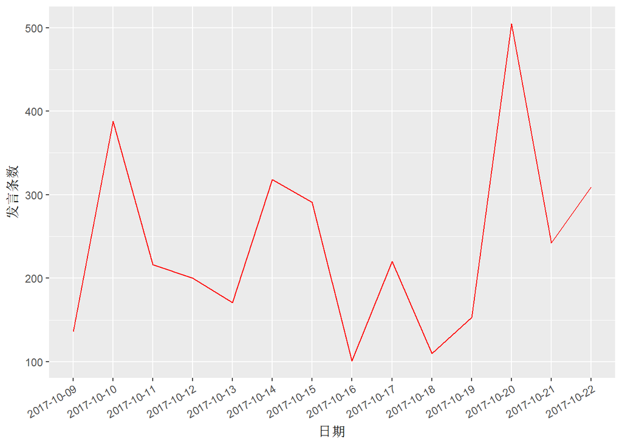

```r
date_freq <- as.data.frame(table(newdata$date))
ggplot(data=date_freq,aes(x=Var1,y=Freq,group=1)) +
  geom_line(color="red") +
  theme(axis.text.x=element_text(angle=30,hjust=1)) +
  xlab("日期") + ylab("发言条数")
```

- 发言时间频率统计

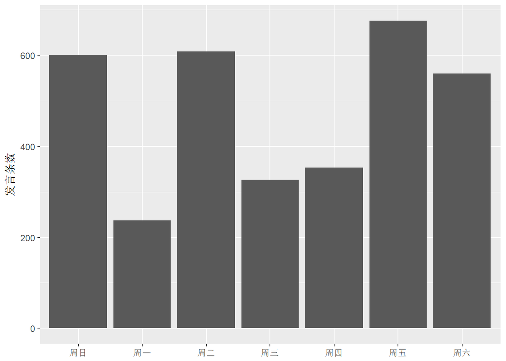

```r
# QQ群的聊天兴致随星期的分布
wday_freq <- as.data.frame(table(newdata$wday))
ggplot(data=wday_freq,aes(x=Var1,y=Freq,group=1)) +
  geom_bar(stat = 'identity') +
  theme(axis.title.x = element_blank()) +
  ylab("发言条数")
```

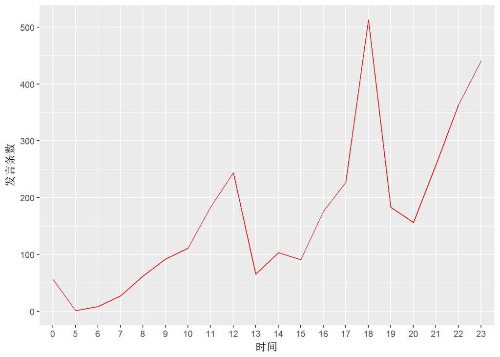

```r
# 聊天兴致在一天中的分布
hour_freq <- as.data.frame(table(newdata$hour))
ggplot(data=hour_freq,aes(x=Var1,y=Freq,group=1)) +
  geom_line(color="red")  +                #折线图和条形图叠加
  xlab("时间") + ylab("发言条数")
```

### 3.2 发言用户统计

- 话痨用户

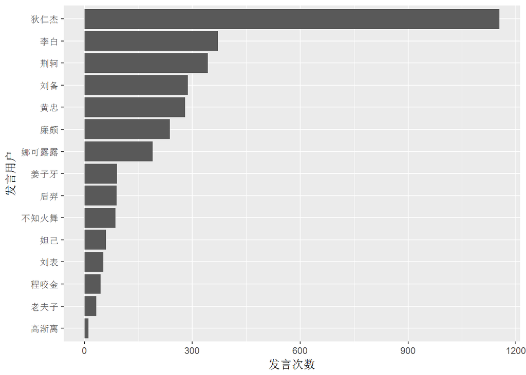

```r
# 记录每个用户发言条数
user <- as.data.frame(table(newdata$id))
user <- user[order(user$Freq,decreasing=T),]
# 存前十大发言人的 ID
topuser <- user[1:10,]$Var1

# 显示前十大发言人的 ID 和 发言次数
ggplot(data=user[1:15,],aes(x=reorder(Var1, Freq),y=Freq))+
  geom_bar(stat='identity') +
  ylab("发言次数") + xlab("发言用户") +
  coord_flip()   # 条形图90度旋转
```

- 活跃用户 活跃天数计算：将数据展开为宽表，每一行为用户，每一列为日期，对应数值为发言次数

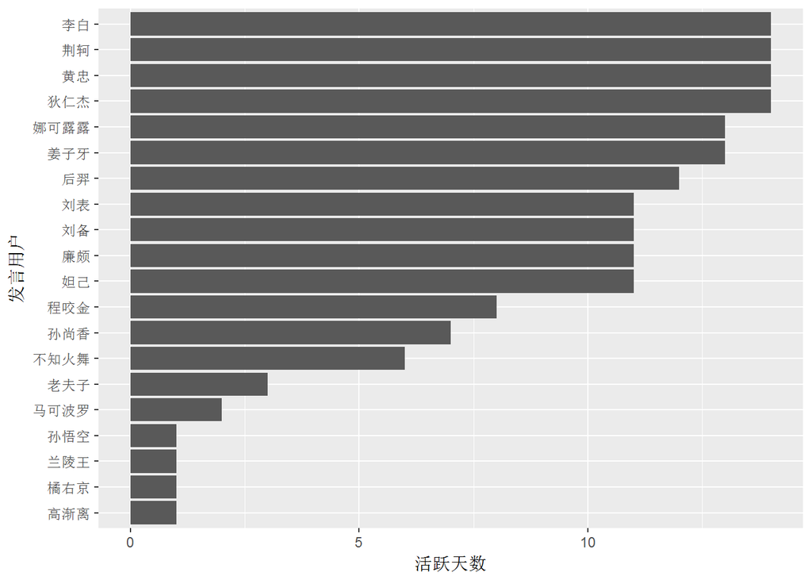

```r
# dcast为reshape包内函数，一般输出双变量数据框
flat.day <- dcast(newdata,id~date,length,value.var='date')
#转为矩阵
flat.mat <- as.matrix(flat.day[-1])

# 转为0-1值，以观察是否活跃
flat.mat <- ifelse(flat.mat>0,1,0)

# 根据上线天数求和
topday <- data.frame(flat.day[,1],apply(flat.mat,1,sum))
names(topday) <- c('id','days')
topday <- topday[order(topday$days,decreasing=T),]

# 获得前十大活跃用户
ggplot(data=topday,aes(x=reorder(id, days),y=days)) +
  geom_bar(stat='identity') +
  ylab("活跃天数") + xlab("发言用户") +
  coord_flip()   # 条形图90度旋转
```

- 每日活跃人数走势图  
  根据flat.day数据观察每天活跃用户变化，numday为每天发言人数

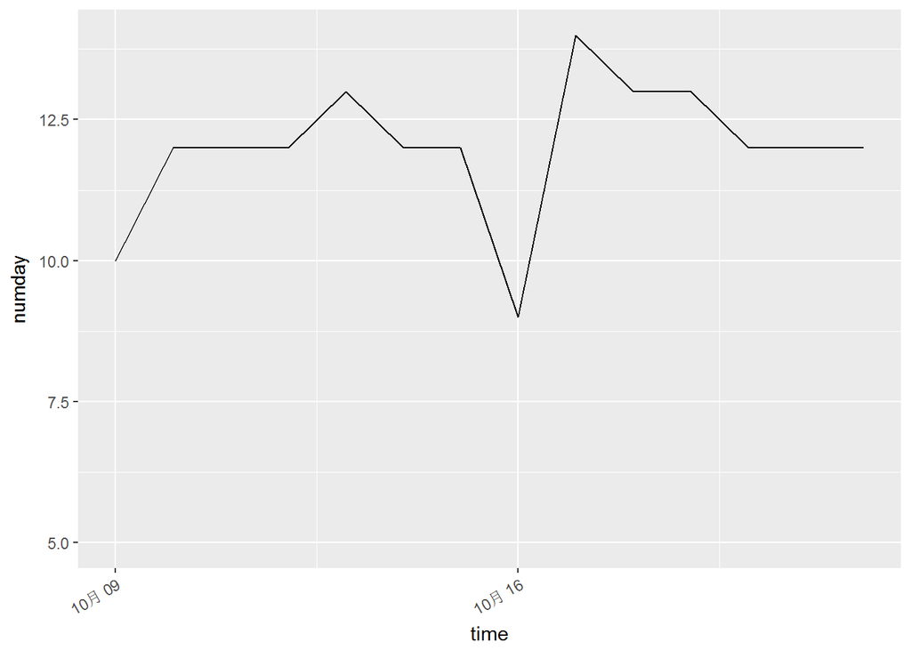

```r
numday <- apply(flat.mat,2,sum)
tempdf <- data.frame(time=ymd(names(numday)),numday)
ggplot(data=tempdf,aes(x=time,y=numday)) +
  geom_line(colors="red") +
  ylim(5,max(numday)) +
  theme(axis.text.x=element_text(angle=30,hjust=1))
```

### 3.3 社交网络分析

- 连续对话数 以三十分钟为间隔

```r
newdata$realtime <- strptime(newdata$time,'%Y-%m-%d %H:%M')
# 时间排序有问题，按时间重排数据
newdata2 <- newdata[order(newdata$realtime),]

# 将数据按讨论来分组
group <- rep(1,dim(newdata2)[1])
for (i in 2:dim(newdata2)[1])
{
  d <- as.numeric(difftime(newdata2$realtime[i],
                           newdata2$realtime[i-1],
                           units='mins'))
  if ( d < 30)
  {
    group[i] <- group[i-1]
  } else {group[i] <- group[i-1]+1}
}
```

- 画社交网络图

```r
# 得到多组对话
newdata2$group <- group
```

```r
newdata3 <- dcast(newdata2, id~group, sum,value.var='group',subset=.(id %in% user[1:20,]$Var1))
newdata4 <- ifelse(newdata3[,-1] > 0, 1, 0)
rownames(newdata4) <- newdata3[,1]
relmatrix <- newdata4 %*% t(newdata4)
```

很容易看出哪两个人聊得最多

```r
deldiag <- relmatrix-diag(diag(relmatrix))
which(deldiag==max(deldiag),arr.ind=T)
```

```
##        row col
## 荆轲     9   4
## 狄仁杰   4   9
```

根据关系矩阵画社交网络图

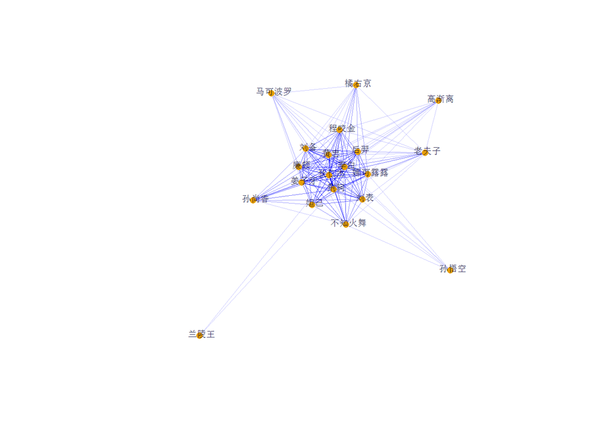

```r
g <- graph.adjacency(deldiag,weighted=T,mode='undirected')
g <-simplify(g)
V(g)$label<-rownames(relmatrix)
V(g)$degree<- degree(g)
layout1 <- layout.fruchterman.reingold(g)
#egam <- 10*E(g)$weight/max(E(g)$weight)
egam <- (log(E(g)$weight)+1) / max(log(E(g)$weight)+1)
#V(g)$label.cex <- V(g)$degree / max(V(g)$degree)+ .2
V(g)$label.color <- rgb(0, 0, .2, .8)
V(g)$frame.color <- NA
E(g)$width <- egam
E(g)$color <- rgb(0, 0, 1, egam)
plot(g, layout=layout.fruchterman.reingold,
     vertex.size=5,
     vertex.label.cex=.6,
     vertex.label.dist=.4)
```

- 最佳拍档

```r
pairlist = data.frame(pair=1:length(attributes(deldiag)$dimnames[[1]]))
rownames(pairlist) <- attributes(deldiag)$dimnames[[1]]
for(i in (1:length(deldiag[1,])))
{
  pairlist[i,1]<-attributes(which(deldiag[i,]==max(deldiag[i,]),arr.ind=T))$names[1]
}
pairlist
```

```
##              pair
## 不知火舞   狄仁杰
## 程咬金     狄仁杰
## 妲己         荆轲
## 狄仁杰       荆轲
## 高渐离     狄仁杰
## 后羿       狄仁杰
## 黄忠       狄仁杰
## 姜子牙     狄仁杰
## 荆轲       狄仁杰
## 橘右京     狄仁杰
## 兰陵王     狄仁杰
## 老夫子     狄仁杰
## 李白       狄仁杰
## 廉颇       狄仁杰
## 刘备       狄仁杰
## 刘表       狄仁杰
## 马可波罗   狄仁杰
## 娜可露露   狄仁杰
## 孙尚香     狄仁杰
## 孙悟空   不知火舞
```

```r
pairmatrix=data.frame(pairA=1:length(attributes(deldiag)$dimnames[[1]]),pairB=1:length(attributes(deldiag)$dimnames[[1]]))
pairmatrix=data.frame(pair=1:length(attributes(deldiag)$dimnames[[1]]))
for(i in (1:dim(deldiag)[1]))
{
  deldiag[i,] <- ifelse(deldiag[i,] == max(deldiag[i,]), 1, 0)
}
deldiag
```

```
##          不知火舞 程咬金 妲己 狄仁杰 高渐离 后羿 黄忠 姜子牙 荆轲 橘右京
## 不知火舞        0      0    0      1      0    0    0      0    0      0
## 程咬金          0      0    0      1      0    0    0      0    0      0
## 妲己            0      0    0      0      0    0    0      0    1      0
## 狄仁杰          0      0    0      0      0    0    0      0    1      0
## 高渐离          0      0    0      1      0    0    0      0    0      0
## 后羿            0      0    0      1      0    0    0      0    0      0
## 黄忠            0      0    0      1      0    0    0      0    0      0
## 姜子牙          0      0    0      1      0    0    0      0    0      0
## 荆轲            0      0    0      1      0    0    0      0    0      0
## 橘右京          0      0    0      1      0    0    0      0    0      0
## 兰陵王          0      0    0      1      0    0    0      0    1      0
## 老夫子          0      0    0      1      0    0    0      0    0      0
## 李白            0      0    0      1      0    0    0      0    0      0
## 廉颇            0      0    0      1      0    0    0      0    0      0
## 刘备            0      0    0      1      0    0    0      0    0      0
## 刘表            0      0    0      1      0    0    0      0    0      0
## 马可波罗        0      0    0      1      0    0    0      0    0      0
## 娜可露露        0      0    0      1      0    0    0      0    0      0
## 孙尚香          0      0    0      1      0    0    0      0    0      0
## 孙悟空          1      0    0      1      0    0    1      0    1      0
##          兰陵王 老夫子 李白 廉颇 刘备 刘表 马可波罗 娜可露露 孙尚香 孙悟空
## 不知火舞      0      0    0    0    0    0        0        0      0      0
## 程咬金        0      0    0    0    0    0        0        0      0      0
## 妲己          0      0    0    0    0    0        0        0      0      0
## 狄仁杰        0      0    0    0    0    0        0        0      0      0
## 高渐离        0      0    0    0    0    0        0        0      0      0
## 后羿          0      0    0    0    0    0        0        0      0      0
## 黄忠          0      0    0    0    0    0        0        0      0      0
## 姜子牙        0      0    0    0    0    0        0        0      0      0
## 荆轲          0      0    0    0    0    0        0        0      0      0
## 橘右京        0      0    1    0    0    0        0        0      0      0
## 兰陵王        0      0    0    0    0    0        0        0      0      0
## 老夫子        0      0    0    0    0    0        0        0      0      0
## 李白          0      0    0    0    0    0        0        0      0      0
## 廉颇          0      0    0    0    0    0        0        0      0      0
## 刘备          0      0    0    0    0    0        0        0      0      0
## 刘表          0      0    0    0    0    0        0        0      0      0
## 马可波罗      0      0    1    0    0    0        0        0      0      0
## 娜可露露      0      0    0    0    0    0        0        0      0      0
## 孙尚香        0      0    0    0    0    0        0        0      0      0
## 孙悟空        0      0    1    0    0    0        0        1      0      0
```